# Data Preparation Report - Knotweed’s Tarping Survey (Dusz et al., 2020)

François-Marie Martin

11/27/2020

# 1 - Reproductibility

# 2 - Data visualisation and exploration

## 2.1 - Data exploration following Zuur *et al.* (2010)

In order to build valid and meaningful models to explain or predict the success/failure of tarping operations for the control of Japanese knotweed *s.l.*, we need first to learn more about our data. Therefore, we thoroughly examined our variables (e.g. outliers, distribution, interactions, colinearity, variance homogeneity, observation independence) mostly following the protocol presented by Zuur *et al.* (2010) for each of our **5 response variables**: *eff_eradication*, *efficiency*, *latest_reg_edges*, *reg_overlaps*, *reg_tarpedarea*.

As our global dataset contains many variables (*p* = 85), it would be interesting to reduce their number in order to spare time for further exploration and analyses. As such, the first steps of our data exploration for each response variable will aim at reducing the dimensionality of the data. First, we will try and see if the *environmental variables* can be coerced into a synthetic variable (e.g. through a PCA). Then, we will investigate correlations among variables as well as potential colinearity. This should have the twofold advantage of improving our understanding of the data and enabling us to remove colinear and too strongly correlated variables. Finally, we will carry on data exploration in various ways in order to detect outliers, identify distributions, heteroscedasticity, univariate and multivariate relationships…

### 2.1.1 - For the response variables related to tarping *efficiency*

The first thing to do here is to prepare the sub-dataset that will be used to model the responses of the *efficiency variables* (i.e. **efficiency**, **eff_eradication** and **high_eff**). To do so, the following steps have been performed:

- We selected the subset of predictors and covariates that will be used to model tarping efficiency;
- We left out the observations that were too recent (installed less than 2 growing seasons ago) and those for which we could not obtain an *efficiency score* (i.e. NA);
- We deleted operations that got prematurely interrupted (e.g. because of vandalism) since there failure results from external causes.
- Finally, we imputed missing values using **Random Forest** and the `missForest` package (Stekhoven & Buehlmann, 2012).

The table below presents the *out-of-bag (OOB) imputation error* estimates for each variables (computed as Mean Squared Error (MSE) for numeric variables, and Proportion of Falsely Classified (PFC) for categorical variables), compared to the number of imputed values (i.e. number of NAs per variable): OOB values around 1 or > 1 indicate that imputations are not reliable. Accordingly, we will keep an eye on the observations that have unreliable imputations if they become **influential observations** in subsequent models (in which case, we will drop them)! For the meaning of the variables, please refer to the attached **documentation**.

|  | nb_imputed_values | oob_error |
| --- | --- | --- |
| latitude | 0 | 0.0000000 |
| longitude | 0 | 0.0000000 |
| elevation | 0 | 0.0000000 |
| goals | 0 | 0.0000000 |
| efficiency | 1 | 2.4813328 |
| eff_eradication | 0 | 0.0000000 |
| high_eff | 3 | 0.1084337 |
| freq_monitoring | 0 | 0.0000000 |
| slope | 0 | 0.0000000 |
| difficulty_access | 0 | 0.0000000 |
| shade | 0 | 0.0000000 |
| forest | 0 | 0.0000000 |
| ruggedness | 0 | 0.0000000 |
| granulometry | 1 | 5.0422853 |
| obstacles | 1 | 7.0861917 |
| flood | 0 | 0.0000000 |
| geomem | 0 | 0.0000000 |
| geotex | 0 | 0.0000000 |
| weedsp_geotex | 2 | 0.1190476 |
| maxveg | 0 | 0.0000000 |
| uprootexcav | 0 | 0.0000000 |
| stand_surface | 0 | 0.0000000 |
| fully_tarped | 0 | 0.0000000 |
| distance | 5 | 1.2067211 |
| tarping_duration | 0 | 0.0000000 |
| stripsoverlap_ok | 15 | 0.3943662 |
| tarpfix_multimethod | 0 | 0.0000000 |
| tarpfix_pierced | 0 | 0.0000000 |
| sedicover_height | 1 | 127.9370435 |
| trench_depth | 0 | 0.0000000 |
| plantation | 0 | 0.0000000 |
| repairs | 1 | 0.3882353 |
| add_control | 2 | 0.1904762 |
| degradation | 3 | 0.2289157 |
| pb_fixation | 3 | 0.1325301 |
| pb_durability | 3 | 0.1566265 |

Now, let’s take a quick look at our dataset.

```
   manager_id     xp_id       latitude       longitude          elevation
 1      :10   10     : 1   Min.   :42.45   Min.   :-121.951   Min.   :   3.00
 20     : 2   11     : 1   1st Qu.:45.52   1st Qu.:  -1.050   1st Qu.:  68.25
 2      : 1   12     : 1   Median :46.79   Median :   2.722   Median : 178.50
 3      : 1   13     : 1   Mean   :46.98   Mean   : -10.152   Mean   : 226.81
 4      : 1   14     : 1   3rd Qu.:48.45   3rd Qu.:   4.835   3rd Qu.: 270.50
 6      : 1   15     : 1   Max.   :52.08   Max.   :  14.083   Max.   :1090.00
 (Other):70   (Other):80
                                               goals      efficiency
 eradicate                                        :24   Min.   : 1.333
 eradicate_and_limit_expansion                    :11   1st Qu.: 6.000
 eradicate_and_limit_expansion_and_limit_dispersal:11   Median : 8.000
 eradicate_and_limit_dispersal                    : 8   Mean   : 7.348
 eradicate_and_limit_expansion_vigour             : 7   3rd Qu.: 8.917
 limit_expansion                                  : 5   Max.   :10.000
 (Other)                                          :20
 eff_eradication high_eff freq_monitoring     slope        difficulty_access
 0:63            0:55     Min.   : 0.00   Min.   : 0.000   Min.   :0.000
 1:23            1:31     1st Qu.: 1.25   1st Qu.: 1.000   1st Qu.:0.000
                          Median : 3.00   Median : 4.000   Median :1.000
                          Mean   : 3.36   Mean   : 4.151   Mean   :2.012
                          3rd Qu.: 3.00   3rd Qu.: 7.000   3rd Qu.:3.000
                          Max.   :15.00   Max.   :10.000   Max.   :9.000

     shade         forest         ruggedness      granulometry
 Min.   :0.0   Min.   : 0.000   Min.   : 0.000   Min.   : 0.000
 1st Qu.:2.0   1st Qu.: 1.000   1st Qu.: 2.000   1st Qu.: 3.000
 Median :3.5   Median : 2.500   Median : 3.000   Median : 4.900
 Mean   :3.5   Mean   : 2.884   Mean   : 3.593   Mean   : 4.498
 3rd Qu.:5.0   3rd Qu.: 5.000   3rd Qu.: 5.000   3rd Qu.: 6.000
 Max.   :8.0   Max.   :10.000   Max.   :10.000   Max.   :10.000

   obstacles          flood        geomem geotex weedsp_geotex maxveg
 Min.   : 0.000   Min.   : 0.000   0:35   0:40   0:65          0:57
 1st Qu.: 0.000   1st Qu.: 0.000   1:51   1:46   1:21          1:29
 Median : 2.000   Median : 2.000
 Mean   : 3.166   Mean   : 3.384
 3rd Qu.: 6.000   3rd Qu.: 7.000
 Max.   :10.000   Max.   :10.000

```

[output cut: 12 more lines]

```
                                                      Mean   : 7.16
                                                      3rd Qu.:10.00
                                                      Max.   :55.00

  trench_depth    plantation repairs add_control degradation pb_fixation
 Min.   :  0.00   0:61       0:50    0:22        0:42        0:68
 1st Qu.:  0.00   1: 9       1:36    1:64        1:44        1:18
 Median : 15.00   2:16
 Mean   : 23.17
 3rd Qu.: 40.00
 Max.   :120.00

 pb_durability
 0:69
 1:17
```

#### 2.1.1.1 - Investigation of correlation structures

##### 2.1.1.1.1 - Multivariate synthesis of environmental variables

We performed a **normed-PCA** on some of our environmental variables for which we do not have strong hypotheses (i.e. *difficulty_access*, *shade*, *forest*, *ruggedness*, *granulometry*) but we kept *slope*, *obstacles*, and *flood* because we suspected they might have a major influence on the success/failure of tarping.

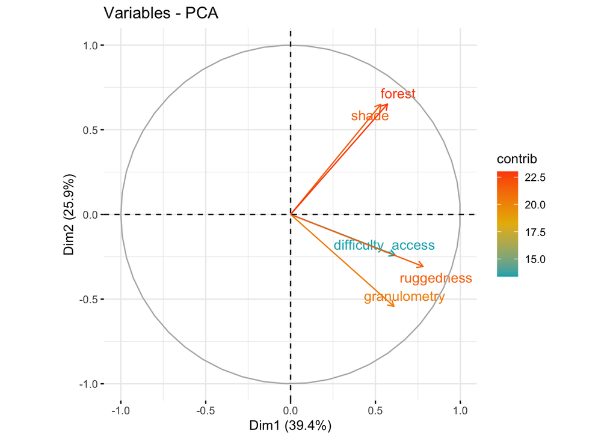

**Figure 1.** Correlation plot of the normed-PCA on environmental variables for the *tarping efficiency* dataset

As the first axis (PC) of our PCA satisfactorily synthesizes a large amount (39.4%) of the variance of the 5 environmental variables, we will use operations’ coordinates on this axis to build a synthetic variable to summarize their environment. This new variable will be named **coarse_env** and will thus replace the other 5 variables in the dataset. Operations with *positive values* for this variable are located in sites that tend to be forested (and thus shaded), difficult to access, with uneven ground and a coarse soil texture (and vice-versa).

##### 2.1.1.1.2 - Correlation among variables

To investigate potential correlations and colinearity among our variables, we will start by computing a **correlation matrix** of the data. As most of our factors are either ordered factors (i.e. ordinal variables) or binary factors (i.e. boolean), we can use them in a correlation matrix. To do that however, computations will be based on *Spearman*’s rank correlation coefficient.  
To avoid giving too much weight to our own tarping experiments (those performed in Chalon s/ Saone with the French national railway company), we removed them from the data to compute correlations: their influence will be accounted for in further analyses by the use of **mixed-effect models**.

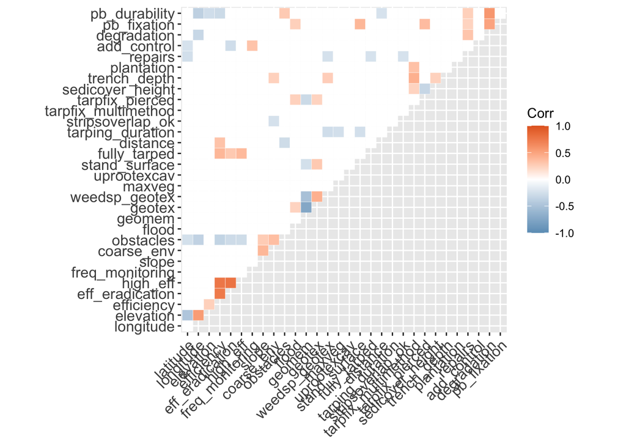

**Figure 2.** Correlation matrix displaying *Spearman*’s $\rho$ for the numeric variables and ordered factors of the *tarping efficiency* dataset. Only significant correlations are displayed (with $\alpha$ = 0.05)

It is worth reminding that accounting for multivariate relationships, interactions and the effect of our tarping operations (dropped for the current correlation matrix) will certainly give very different patterns.

##### 2.1.1.1.3 - Multicollinearity

As multicollinearity is one of the biggest issues for inference modelling, we need to assess which explanatory variables and covariates are collinear and will possibly become problematic for modelling. To do so, our intention was to compute *Variance Inflation Factors* (VIF) for each variable. However, as several variables are categorical and as we will not be working with models fitted with ordinary least squares, we will rather use *Generalized VIF* (Fox & Monette, 1992).

|  | GVIF | Df | GVIF^(1/(2*Df)) |
| --- | --- | --- | --- |
| latitude | 2.859519 | 1 | 1.691011 |
| longitude | 2.812353 | 1 | 1.677007 |
| elevation | 2.576005 | 1 | 1.604994 |
| freq_monitoring | 1.661740 | 1 | 1.289085 |
| slope | 3.124984 | 1 | 1.767762 |
| coarse_env | 2.426367 | 1 | 1.557680 |
| obstacles | 2.411741 | 1 | 1.552978 |
| flood | 2.128421 | 1 | 1.458911 |
| geomem | 5.287622 | 1 | 2.299483 |
| geotex | 5.103727 | 1 | 2.259143 |
| weedsp_geotex | 4.928302 | 1 | 2.219978 |
| maxveg | 1.828249 | 1 | 1.352128 |
| uprootexcav | 2.112890 | 1 | 1.453578 |
| stand_surface | 1.618237 | 1 | 1.272099 |
| fully_tarped | 1.627569 | 1 | 1.275762 |
| distance | 1.802021 | 1 | 1.342394 |
| tarping_duration | 1.727526 | 1 | 1.314354 |
| stripsoverlap_ok | 1.966435 | 1 | 1.402296 |
| tarpfix_multimethod | 2.249653 | 1 | 1.499884 |
| tarpfix_pierced | 3.268860 | 1 | 1.807999 |
| sedicover_height | 1.996209 | 1 | 1.412872 |
| trench_depth | 2.832262 | 1 | 1.682933 |
| plantation | 5.056364 | 2 | 1.499545 |
| repairs | 2.094620 | 1 | 1.447280 |
| add_control | 1.949544 | 1 | 1.396261 |
| degradation | 2.702284 | 1 | 1.643863 |
| pb_fixation | 2.079098 | 1 | 1.441908 |
| pb_durability | 2.864364 | 1 | 1.692443 |

- The variables *geomem* and *geotex* (and *weedsp_geotex*) are, without a surprise, problematic as they contain the same information. Therefore, we decide to only keep *geomem*.
- The *plantation* variable also seems highly problematic. Yet, as we have a strong interest in that variable, we choose to drop it **only temporarily**, only to detect other problematic variables. A particular attention to multicollinearity should be maintained when this variable will be included within models.
- Since our dataset contains sites on both sides of the Atlantic and since we do not have strong hypotheses regarding the effects of *longitude* (because our sites are located well within the longitudinal range of knotweeds), we decide to drop it.
- Since *degradation* contains most of the information contained in *pb_fixation* and *pb_durability*, we decide to drop it to reduce the number of variables.

After iteratively dropping these collinear variables and re-assessing GVIF values, we obtain a subset of potential explanatory variables with GVIF values globally < 3 and GVIF values will likely be even lower in later stages as models will not include so many variables at the same time. Naturally, we will also bear in mind the potential effects of the dropped variables in the discussion.

|  | x |
| --- | --- |
| latitude | 1.826744 |
| elevation | 1.912586 |
| freq_monitoring | 1.421538 |
| slope | 2.292544 |
| coarse_env | 1.913352 |
| obstacles | 2.091820 |
| flood | 1.713074 |
| geomem | 1.648708 |
| maxveg | 1.762535 |
| uprootexcav | 1.693859 |
| stand_surface | 1.370558 |
| fully_tarped | 1.534913 |
| distance | 1.588705 |
| tarping_duration | 1.371186 |
| stripsoverlap_ok | 1.799025 |
| tarpfix_multimethod | 1.739591 |
| tarpfix_pierced | 2.731386 |
| sedicover_height | 1.598609 |
| trench_depth | 2.254270 |
| repairs | 1.900451 |
| add_control | 1.897020 |
| pb_fixation | 1.367364 |
| pb_durability | 1.651190 |

#### 2.1.1.2 - Distributions and dispersion parameters

##### 2.1.1.2.1 - Looking for outliers

We will look for potential outliers in the data using **boxplots** and **Cleveland dotplots** on our quantitative variables.

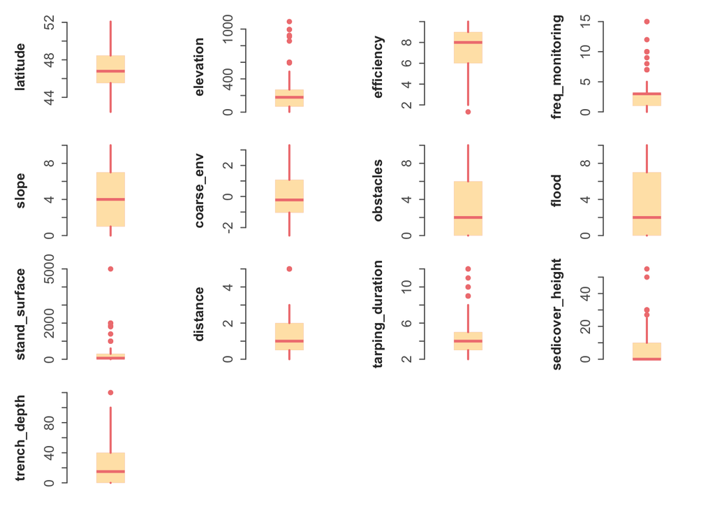

**Figure 3.** Boxplots for all quantitative variables of the *eradication efficiency* dataset

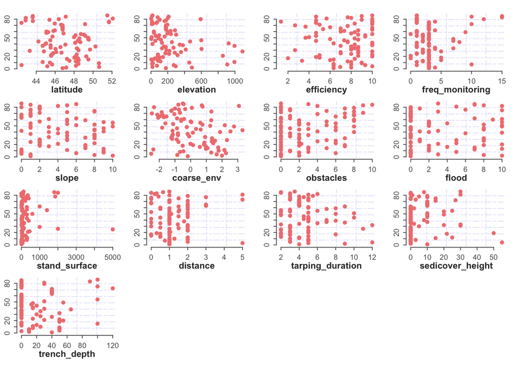

**Figure 4.** Cleveland dotplots for all quantitative variables of the *eradication efficiency* dataset

By the look of these graphs, it is clear that we have many *extreme values* (possible outliers). Yet, extreme values are not necessarily **true outliers**:

- The variables *latitude*, *slope* and *coarse_env* look fine.
- The variables *efficiency*, *obstacles*, *flood*, *distance*, *tarping_duration*, and *trench_depth* may require mild transformations to be normalized but do not seem to contain too extreme values.
- The variables *elevation*, *freq_monitoring*, and *sedicover_height* may require important transformations to be normalized. It would be interesting to see if their extreme values are too far from what could be expected from a Normal or a Poisson distribution (see below).
- The *stand_surface* variable contains a problematic patterns/outliers.

After analysing random samples drawn from log-normal distributions (based on the parameters of our potentially problematic variables), we have good reason to believe that only *stand_surface* should be problematic. Consequently, we choose to delete the spotted outlier within *stand_surface* (i.e. the *stand_surface* of ca. 5000 m<sup>2</sup>).  
The other variables do not have distribution that a transformation could not fix. We will see later on whether we actually need such transformation (e.g log) or not.

##### 2.1.1.2.2 - Normality

We already got a pretty good idea of the distribution of our variables and not all statistical methods involve a Normality assumption (for instance, multiple linear regressions assume that residuals are normally distributed, not the variable themselves). Still, it’s interesting and often useful to have a precise view of variables distributions, even for predictors and covariates.

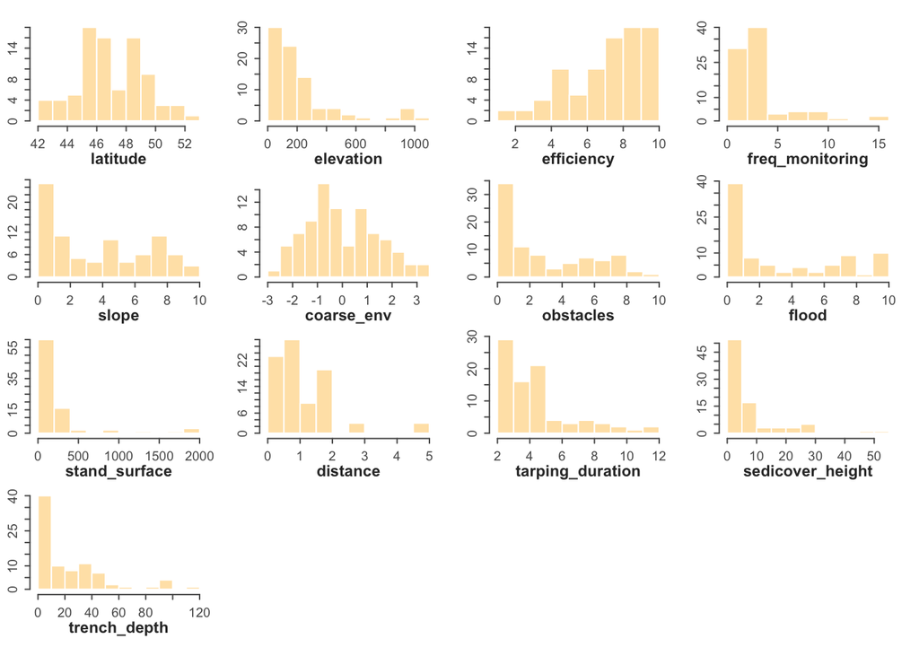

**Figure 5.** Histograms for all quantitative variables of the *eradication efficiency* dataset

#### 2.1.1.3 - Bivariate relationships

##### 2.1.1.3.1 - Relationships among variables

The next step in our data exploration is to plot the response variables against each predictors and covariates in order to assess the **linearity** and **homoscedasticity** assumptions as well as identify potential **interactions** and **multivariate outliers**. It would be interesting to plot all variables against each other, but we have too many potential predictors and covariates for that.

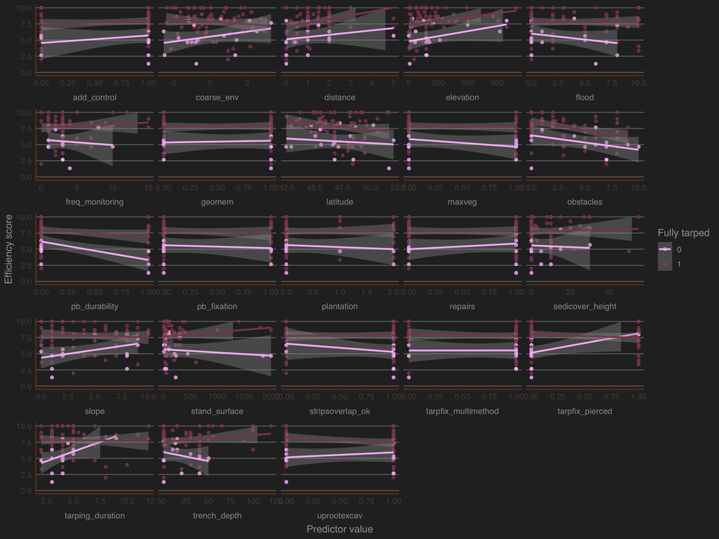

**Figure 6.** Multivariate representation of the *efficiency score* against each potential explanatory variable with a focus on whether knotweed stands were fully tarped or not

Various interesting observations can be made from these scatterplots:

- First, heteroscedasticity will perhaps not be surprising in our models as the variances of many variables do not seem to be homogeneous. On the other hand, we do not see clear multivariate outliers.
- Second, the *efficiency* score seems to increase with increasing *distance*. This may be evidence in support to one of our working hypotheses stating that successful tarping operations cover areas well beyond the visible limits of knotweed stands. Conversely, the *efficiency* score seems to decrease with increasing presence of *obstacles* and with *pb_durability*.
- Third, surprisingly, the *efficiency* score also seems to increase with increasing *elevation*. If this is not due to measurement error, then it could be a sign of stronger abiotic constraints on knotweeds. *Additional control* similarly seems to improve *efficiency*.
- Fourth, there may be signs of interesting interactions between the *fully tarped* variable and *coarse_env*, *pb_durability*, *slope*, *stand_surface*, *tarpfix_pierced*, *tarping_duration*, *trench_depth* and *uprootexcav*, although caution is required as variances are quite high. Furthermore, if interactions with *stand_surface* or *pb_durability* are relatively straightforward, the other ones are trickier do grasp and could simply be spurious.

To further investigate multivariate relationship, we will create another set of scatterplots (but we do not intend on investigating all possible combinations between variables).

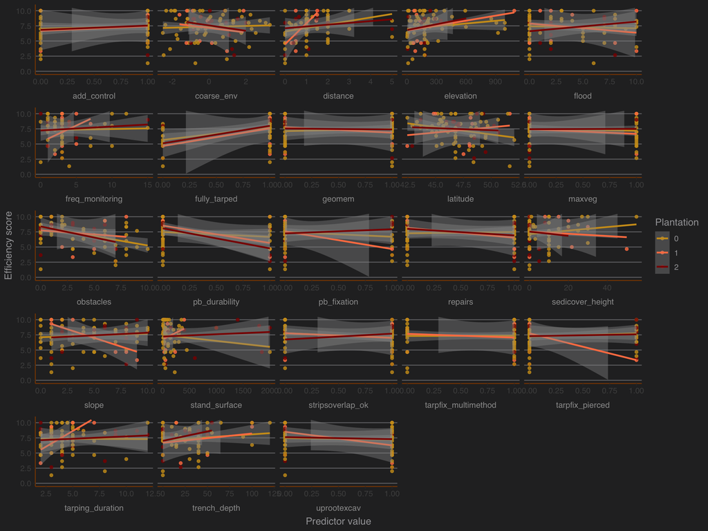

We can see from this new panel of plots that the *efficiency* score seems to increase when knotweeds are *fully tarped*, as we hypothesized.

## 2.2 Next steps for preparation

2. Write other preparation chapters! Terminate excel_model and send it…
3. Set drake?
4. Transformations and standardization (for scaling, especially important when I use interactions terms; cf. “standardization” post on CV in my MacBook favorites)